# STA 305 FINAL PROJECT

Jacky Guan

Dec 10th, 2023

Loading required libraries, setting local working directory for reference.

### Introduction to the General Social Survey (GSS)

The General Social Survey (GSS) stands as a monumental undertaking in the field of social research, providing a comprehensive and longitudinal examination of the attitudes, behaviors, and demographic characteristics of the American population. Initiated in 1972 by the National Opinion Research Center (NORC) at the University of Chicago, the GSS has since evolved into one of the most influential and widely used resources in the social sciences, shaping our understanding of societal trends and shifts over the past five decades.

The idea of the GSS first came into play when the American scientific community realized there was a need for systematic and  
in-depth data on the social fabric of our society. Developed under the best sociologists at the time, the survey aimed to explore a diverse range of topics, including social inequality, political participation, and cultural attitudes. Through a meticulously crafted questionnaire traditinally asked during in-person interviews, the GSS sought to capture the nuances within the dynamic nature of American social life.

Over the years, the GSS has undergone methodological refinements and expansions to ensure its relevance and reliability. The survey’s scope has expanded to cover an extensive array of topics, from political affiliations and religious beliefs to family dynamics and technological adoption. Researchers, policymakers, and scholars have consistently turned to the GSS for its reliability when it comes to representing America, enabling a deeper understanding of societal trends and informing evidence-based decision-making.

However, the GSS, like many other aspects of life, faced an unprecedented challenge after the start of the COVID-19 pandemic caused by the CCP virus. The global health crisis disrupted traditional modes of data collection, prompting the GSS to adapt swiftly to ensure the continuity of its mission. The pandemic introduced new considerations, such as the impact of social distancing measures on social interactions and the potential amplification of existing inequalities in the face of health and economic challenges. At the same time, there were numerous obstacles to overcome in upholding the quality of the historically robust dataset as in person interviews were becoming increaingly challanging to overcome. Nevertheless, the GSS continues to be one of the most important assets in social research and has become ever so diverse in covering avant-garde topics using innovative methods.

### Exploring Workplace Harassment in 2016

In 2016, the General Social Survey (GSS) introduced a significant inquiry concerning workplace dynamics, focusing on the prevalence of harassment at work. This pivotal question aimed to gauge respondents’ experiences with harassment from superiors or co-workers over the preceding five years, encompassing instances of bullying, physical, or psychological abuse. The responses to this specific question are stored within the “harass5” variable in the dataset from the year 2016.

As we look into the answers, our first questions aim to figure out how people responded to this workplace harassment question. We want to know the different responses recieved by the survey and the frequency of each answer. Through these inquiries, we aim to unravel some details pertaining to workplace harassment, shedding light on both the overall prevalence and the nuanced gender dynamics within this critical facet of the professional realm.

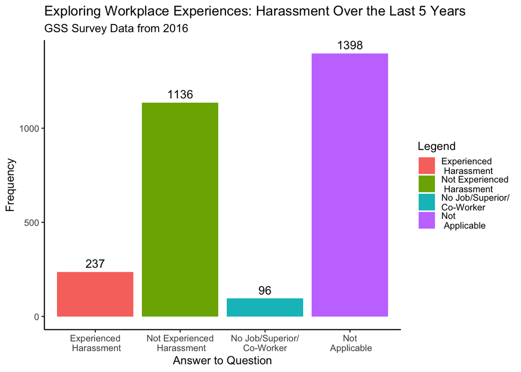

The next question is about finding out how common workplace harassment is among the people who answered this question. Cases where people didn’t respond or said the question didn’t apply will not be considered.

Out of those people who found the question to be relevant or applicable, 77% of respondents said that they did not experience any workplace harassment. While 7% were not in a situation to even be able to be harassed, 16% of this subset of respondents said that they were harassed at some point during the past 5 years.

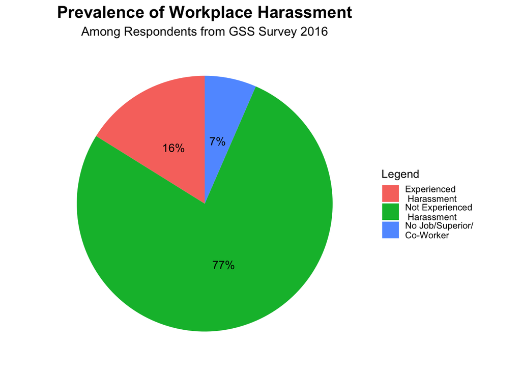

Moving on, we’re also looking at the gender breakdown among those who said they’ve experienced harassment. We want to see the proportion of men and women who’ve been through workplace harassment, getting insights into any differences based on gender.

While it is true that a simple majority of those surveyed who have been through harassment were women they do not dominate the field of being a victim, as women account for only 56% of those harassed, while the remaining 44% in those who experienced harassment were men.

```
## # A tibble: 2 × 3
##   sex    count proportion
##   <chr>  <int>      <dbl>
## 1 Female   132      0.557
## 2 Male     105      0.443
```

### Family Origin

> What is your country of Family Origin

America is the melting pot of the world. It is historically known as the land of immigrants and has perhaps so forged one of the most powerful economies of the world. Perhaps due to this positive feedback look, America has attracted people from a diverse range of people from around the world.

Renowned for its historical role as a diverse nation of immigrants, the U.S. has undergone demographic shifts key to shaping the composition of American families. This next section will investigate changes in family origin patterns in the United States from the mid 1990s to the late 2010s. Analyzing data over time, our graphical representation aims to offer insights into the evolution of family origin dynamics.

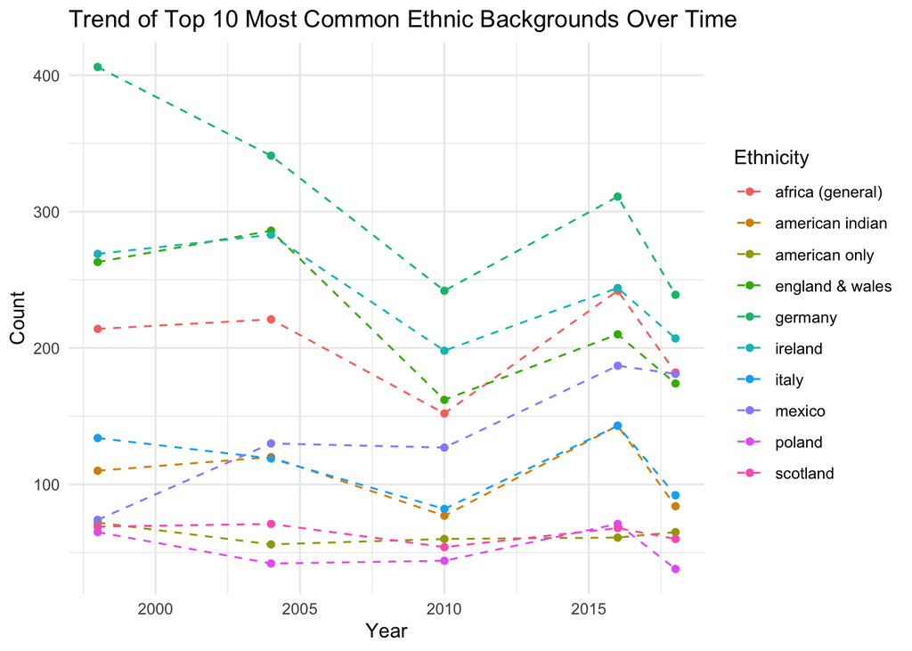

The comprehensive analysis of ethnic background trends in the United States over the past two decade reveals intriguing shifts that shape the nation’s demographic landscape. Notably, there is a discernible decline in individuals of European origin, particularly from countries such as Ireland, Germany, and Italy. This downward trajectory suggests evolving migration patterns or assimilation trends within these communities. Concurrently, the emergence of a growing Mexican population stands out as a prominent feature, indicating a dynamic transformation in the ethnic composition of the country.

The observation that American Indian backgrounds are also experiencing a decline prompts further investigation into the factors influencing this shift. Perhaps this is due to a exacerbated cultural dilution in recent years which accelerated the dissapearance of the indigenous people, or simply due to a reduced number of people willig to identify with the ethnic group.

At the same time, it is interesting that the number of people who identified as being African suddenly increased at a rate greater than the other countries in 2016. While an increase in immigrants could be a potential factor, cultural influences such as a African-American president leaving the office could ignitige cultural trends that will influence the people’s opinion.

It is important to note that given my limited technical expertise and the sheer difficulty of this assignment, it was not possible to plot the relative percentages of the various datapoints which causes this graph to be a little difficult to read. Durin these few years selected, the GSS dataset consistently hovered around the 2500 respondent mark, which means that despite the numbers being emperically different, it is still possible for one to draw graphical conclusions. Notwithstanding, the ten most popular countries of origin, especially Mexico, wield a substantial influence on the overall demographic makeup. The high population of these countries, their geographic location, or even the language thereof all likely contributes to said culture’s prominence in the United States.

### Public Opinion on China in 1994

> How much do you like China

In 1994, the relationship between the United States and China underwent significant developments, marked by a complex interplay of diplomatic engagements, economic ties, and regional dynamics. Against the backdrop of a post-Cold War era, both nations sought to redefine their relationship within the shifting global geopolitical landscape. One pivotal event during this period was the formalization of diplomatic ties through the establishment of the U.S.-China Joint Liaison Group, providing a structured platform for ongoing dialogue between the two nations. This diplomatic initiative laid the groundwork for addressing mutual concerns and fostering a framework for cooperation.

Economic considerations played a crucial role in shaping the relationship as well, with the normalization of trade relations between the United States and China in 1994. The conclusion of the U.S.-China trade agreement paved the way for increased economic collaboration and trade liberalization, setting the stage for the subsequent expansion of bilateral trade between the two nations. Concurrently, China’s economic reforms and opening-up policies were gaining momentum, contributing to its growing integration into the global economy.

The regional landscape was further influenced by the complex issue of Taiwan. In 1994, the United States and China navigated a delicate situation following President Bill Clinton’s approval of a U.S. visa for Taiwan’s President Lee Teng-hui. This decision stirred tensions, prompting a recalibration of diplomatic engagements and highlighting the intricacies of managing relationships in the Asia-Pacific region. The events of 1994 thus reflect a pivotal juncture in U.S.-China relations, characterized by diplomatic milestones, economic cooperation, and the careful negotiation of regional dynamics.

Analysts today would argue that the United States, while remaining hopeful to influence communist China with Western money and as a supposed consequence, democracy, has failed to stop the expansion of communism and made the totalitarian regime rich while almost 700 million Chinese live with a monthly salary not far from $140. But when this pivotal moment in history began, what did the public think of China?

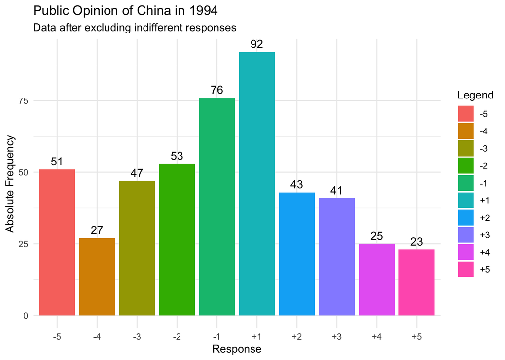

In general, the public opinion was not very favorable towards China, as a simple majority of people (254/478 or 53.1%) held negative or very negative views towards China. At the same time, most people did not hold extremely negative or positive views towards China in 1994. In fact, most people did not have a view on China at all, as there were 2514/2992 or 84% of respondents who simply declined to comment.

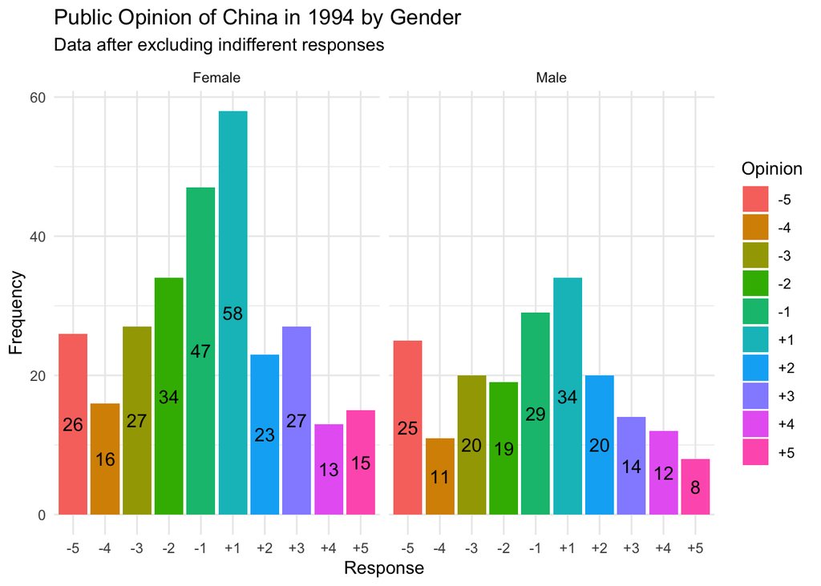

In this sample, Women, who are traditionally less interested in politics than men, were more inclined to comment on this issue. On the one side, it might be that women have a general tendency to have an opinion on most subjects or that the number of women in the United States is simply greater than that of men. On the other hand, it might be becuase the Men, while they watch the news and see what’s going on in the world and how the American government is interacting with the Chinese government, that they become more cautious when commenting on current affairs.

It is interesting to note that this question has never been asked again

### How does the US “Work” in 2018

In 2018, the United States witnessed several significant economic events that played a crucial role in shaping the employment landscape and overall economic conditions, which many would attribute to the election of Donald J. Trump and the associated economic policies.

#### Tax Cuts and Jobs Act (TCJA):

One of the most impactful economic developments in 2018 was the implementation of the Tax Cuts and Jobs Act. Enacted in December 2017, this sweeping tax reform brought about significant changes to the tax structure, including corporate tax rate reductions and modifications to individual tax brackets. The aim was to stimulate economic growth, encourage job creation, and boost overall productivity. The TCJA had widespread implications for businesses and individuals alike, influencing hiring trends and workforce dynamics.

#### Low Unemployment Rates:

Throughout 2018, the United States experienced historically low unemployment rates. The job market thrived, with unemployment reaching levels not seen in decades. The robust labor market presented opportunities for job seekers, with employers competing for talent across various industries. This economic environment contributed to a dynamic and competitive job market, influencing individuals’ decisions regarding employment, career choices, and work-life balance.

#### Trade Tensions and Tariffs:

The escalating trade tensions between the United States and its major trading partners, particularly China, marked a defining economic feature of 2018. The imposition of tariffs and retaliatory measures had a direct impact on certain industries and sectors, influencing business strategies and employment patterns. The uncertainties surrounding international trade relations during this period had implications for job stability and the overall economic outlook, prompting individuals and businesses to adapt to changing market conditions.

The question remains: does the data support the research?

Under these conditions, the employment data from the GSS provides a robust dataframe for analysis. It is not difficult to see that a majority (59%) of pepole are either working full time or part time in 2018 and that the employment rate of 3.5% is a clear indicator of a healthy economy. At the same time, 19% of respondents were retired, which accounts for almost 1/5 of the economy. This is within the bounds of a normal and well-functioning economy.

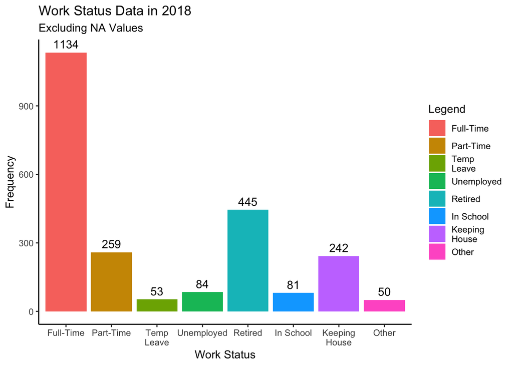

Often times, it is easier to visualize and quantify issues using alternative forms of graphs, which can be seen below. Here it is easier to see that almost half of the American population is working full time. On a side note, a significant amount of people (10%) simply stay at home and do housekeeping, which might also be an indication that the economy is doing well since a person can stay at home in the house while the other brings in the money.

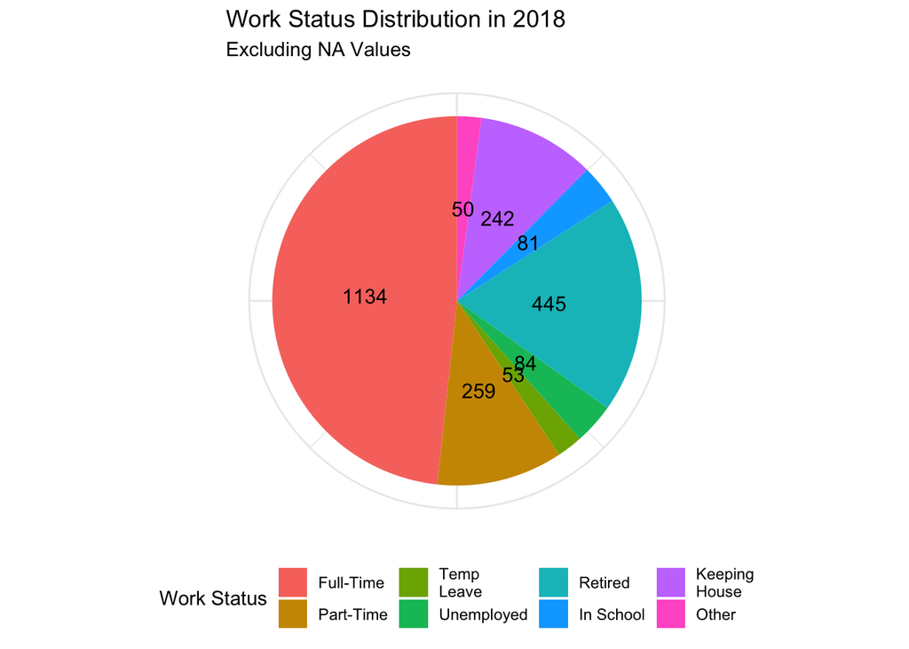

### Conclusion and Closing Remarks

In the course of this project, the relatively short duration posed a challenge in fully exploring and visualizing complex datasets using R. The limited proficiency in R further constrained the capacity to create sophisticated visualizations that could provide a comprehensive overview of the data. Despite these constraints, efforts were directed towards finding engaging topics and subsequently seeking relevant data to support the findings. The project aimed to derive insights into public sentiments towards China in 1994, assess the economic landscape of the United States in 2018, and explore the shifting demographic patterns, particularly the increasing presence of Mexicans in the United States.

Through this project and exploring the gigantic gss dataset, it became apparent that the data suggested a general lack of substantial interest in China among the surveyed population in 1994. In 2018, the available data indicated a robust and flourishing American economy. Furthermore, a notable observation emerged regarding the demographic trends, with an apparent rise in the Mexican population in the United States.

However, it is crucial to acknowledge the inherent complexity and nuance in these issues. Demographics, the economy, and geopolitical sentiments are not issues that can be expressed using 1’s and 0’s, but something which can be supported through data. This is why research was always conducted first prior to the visualization of data.

It is due to the fact that limitations of drawing definitive conclusions based solely on data underscored the need for a more comprehensive and multifaceted approach to understanding the dynamics of public opinion, economic conditions, and demographic shifts. The project, while providing valuable insights, recognized the intricate nature of these topics and the challenges in making conclusive statements based solely on quantitative data.